# Table of Contents

**Kernel Author:**  
[Bhishan Poudel, Data Scientist, Ph.D Astrophysics](https://bhishanpdl.github.io/) .

# Data Description

This dataset contains house sale prices for King County, which includes Seattle. It includes homes sold between May 2014 and May 2015.

- Dependent features: 1 (price)
- Features : 19 home features
- Id: 1 house ID

Task: Try to estimate the price based on given features.

[figure not shown]

# Notes for Linear Regression

- Linear regression models are highly intepretable and have low complexity.
- We can have effect of each features to target.
- High Adjusted R-squared value is better.
- Durbin Watson test is for one order AR(1), i.e. to test whether a time series x(t) has correlation with x(t-1).
- Low p-values are better.
- High F-statistics are better. If data has too many rows, even low F1 value can be good.
- They can have high bias (low model complexity) but low variance.
- High bias means we might need more complex model to fit the real life data there might not be linear relation between predictors (X) and target (y).
- High variance means when we change few data points of the dataset, model gives very different parameters. Linear model does not have this problem.
- There are many test whether linear regressin can be fitted to a data for not. i.e. data should follow the assumptions of linear regression to give a resonable result.
- Log transform helps making the continuos data more Gaussian-like and it linear models benifits from it.

# General Modelling Tips

- Always use random state for code reproducibility. Linear Regression does not have random state, but regularized versions L1 (Lasso, makes coeffs 0), L2(Ridge, makes coeffs close to zero) have random state.
- Always use njobs=-1 to utilize all cores in your laptop.
- You can use RandomizedSearchCV for hyperparameter tuning with njobs=-1. We can make it little bit faster with dask backend: https://github.com/dask/dask-examples/blob/master/machine-learning/scale-scikit-learn.ipynb

```
# sklearn is slower
from sklearn.model_selection import GridSearchCV
grid_search = GridSearchCV(model, param_grid,cv=5,n_jobs=-1
                           scoring='accuracy',verbose=2,random_state=random_state)

grid_search.fit(Xtrain, ytrain)


# using dask is faster
import dask
import joblib

with joblib.parallel_backend('dask'):
    grid_search.fit(Xtrain, ytrain)
```

# Imports

```python
%%javascript
IPython.OutputArea.auto_scroll_threshold = 9999;
```

```python
ENV_BHISHAN = None

try:
    import bhishan
    %load_ext autoreload
    %autoreload 2

    ENV_BHISHAN = True

    print('Environment: Bhishan')
except:
    pass
```

```
Environment: Bhishan
```

```python
import numpy as np
import pandas as pd
import seaborn as sns
sns.set(color_codes=True)

import matplotlib
import matplotlib.pyplot as plt
%matplotlib inline

import os
import time

import io
import json

# random state
SEED=100
np.random.seed(SEED) # we need this in each cell


# Jupyter notebook settings for pandas
pd.set_option('display.max_columns', 200)
pd.set_option('display.float_format', '{:,.3f}'.format) # numbers sep by comma
pd.set_option('display.max_rows', 100) # None for all the rows
pd.set_option('display.max_colwidth', 200)

print([(x.__name__,x.__version__) for x in [np, pd,sns,matplotlib]])
```

```
[('numpy', '1.16.4'), ('pandas', '0.25.2'), ('seaborn', '0.9.0'), ('matplotlib', '3.1.1')]
```

```python
# scale and split
from sklearn.model_selection import train_test_split
```

```python
# regressors
from sklearn import linear_model
from sklearn.linear_model import LinearRegression
```

```python
# regressor preprocessing
from sklearn.preprocessing import StandardScaler, MinMaxScaler
from sklearn.preprocessing import PolynomialFeatures
```

```python
# metrics
from sklearn import metrics
from sklearn.metrics import mean_squared_error
```

```python
# cross validation
from sklearn.model_selection import cross_val_score
```

# Useful Scripts

```python
def show_method_attributes(obj, ncols=7,start=None, inside=None):
    """ Show all the attributes of a given method.
    Example:
    ========
    show_method_attributes(list)
     """

    print(f'Object Type: {type(obj)}\n')
    lst = [elem for elem in dir(obj) if elem[0]!='_' ]
    lst = [elem for elem in lst
           if elem not in 'os np pd sys time psycopg2'.split() ]

    if isinstance(start,str):
        lst = [elem for elem in lst if elem.startswith(start)]

    if isinstance(start,tuple) or isinstance(start,list):
        lst = [elem for elem in lst for start_elem in start
               if elem.startswith(start_elem)]

    if isinstance(inside,str):
        lst = [elem for elem in lst if inside in elem]

    if isinstance(inside,tuple) or isinstance(inside,list):
        lst = [elem for elem in lst for inside_elem in inside
               if inside_elem in elem]

    return pd.DataFrame(np.array_split(lst,ncols)).T.fillna('')
```

```python
df_eval = pd.DataFrame({'Model': [],
                           'Details':[],
                           'Root Mean Squared Error (RMSE)':[],
                           'R-squared (training)':[],
                           'Adjusted R-squared (training)':[],
                           'R-squared (test)':[],
                           'Adjusted R-squared (test)':[],
                           '5-Fold Cross Validation':[]})
```

```python
%%javascript
IPython.OutputArea.auto_scroll_threshold = 9999;
```

# Load the data

```python
!ls ../data/processed/
```

```
data_cleaned.csv         data_cleaned_encoded.csv
```

```python
ifile = 'https://github.com/bhishanpdl/Project_House_Price_Prediction/blob/master/data/processed/data_cleaned_encoded.csv?raw=true'
ifile = '../data/processed/data_cleaned_encoded.csv'
df_raw = pd.read_csv(ifile)
print(df_raw.shape)
df_raw.head()
```

```
(21613, 92)
```

|  | id | date | price | bedrooms | bathrooms | sqft_living | sqft_lot | floors | waterfront | view | condition | grade | sqft_above | sqft_basement | yr_built | yr_renovated | zipcode | lat | long | sqft_living15 | sqft_lot15 | yr_sales | age | yr_renovated2 | age_after_renovation | zipcode_top10 | zipcode_houses | basement_bool | renovation_bool | … |
| --- | --- | --- | --- | --- | --- | --- | --- | --- | --- | --- | --- | --- | --- | --- | --- | --- | --- | --- | --- | --- | --- | --- | --- | --- | --- | --- | --- | --- | --- | --- |
| 0 | 7129300520 | 2014-10-13 | 221,900.000 | 3 | 1.000 | 1180 | 5650 | 1.000 | 0 | 0 | 3 | 7 | 1180 | 0 | 1955 | 0 | 98178 | 47.511 | -122.257 | 1340 | 5650 | 2014 | 59 | 1955 | 59 | others | 262 | 0 | 0 | … |
| 1 | 6414100192 | 2014-12-09 | 538,000.000 | 3 | 2.250 | 2570 | 7242 | 2.000 | 0 | 0 | 3 | 7 | 2170 | 400 | 1951 | 1991 | 98125 | 47.721 | -122.319 | 1690 | 7639 | 2014 | 63 | 1991 | 23 | others | 410 | 1 | 1 | … |
| 2 | 5631500400 | 2015-02-25 | 180,000.000 | 2 | 1.000 | 770 | 10000 | 1.000 | 0 | 0 | 3 | 6 | 770 | 0 | 1933 | 0 | 98028 | 47.738 | -122.233 | 2720 | 8062 | 2015 | 82 | 1933 | 82 | others | 283 | 0 | 0 | … |
| 3 | 2487200875 | 2014-12-09 | 604,000.000 | 4 | 3.000 | 1960 | 5000 | 1.000 | 0 | 0 | 5 | 7 | 1050 | 910 | 1965 | 0 | 98136 | 47.521 | -122.393 | 1360 | 5000 | 2014 | 49 | 1965 | 49 | others | 263 | 1 | 0 | … |
| 4 | 1954400510 | 2015-02-18 | 510,000.000 | 3 | 2.000 | 1680 | 8080 | 1.000 | 0 | 0 | 3 | 8 | 1680 | 0 | 1987 | 0 | 98074 | 47.617 | -122.045 | 1800 | 7503 | 2015 | 28 | 1987 | 28 | others | 441 | 0 | 0 | … |

# Simple Linear Regression

> Simple linear model has only one feature and one target. Here our target is price. From the correlation plot, I see that sqft_living is the most important feature. So, I will build a simple linear regression with sqft_living vs price.

$$ h_{\theta}(X)=\theta_{0}+\theta_{1} x $$

```
theta_0 = lr.intercept_
theta_1 = lr.coef_
```

```python
df_corr = df_raw.corr(method='pearson')

cols10 = df_corr.nlargest(10, 'price').index

df_corr = df_raw[cols10].corr()
df_corr.style.background_gradient(cmap='coolwarm', axis=None)
```

|  | price | log1p_price | sqft_living | grade | log1p_sqft_living | sqft_above | sqft_living15 | log1p_sqft_living15 | log1p_sqft_above | bathrooms |
| --- | --- | --- | --- | --- | --- | --- | --- | --- | --- | --- |
| price | 1 | 0.891654 | 0.702035 | 0.667434 | 0.611757 | 0.605567 | 0.585379 | 0.544014 | 0.542774 | 0.525138 |
| log1p_price | 0.891654 | 1 | 0.695341 | 0.703634 | 0.67494 | 0.601802 | 0.619312 | 0.607201 | 0.586322 | 0.550802 |
| sqft_living | 0.702035 | 0.695341 | 1 | 0.762704 | 0.954368 | 0.876597 | 0.75642 | 0.732194 | 0.84324 | 0.754665 |
| grade | 0.667434 | 0.703634 | 0.762704 | 1 | 0.743711 | 0.755923 | 0.713202 | 0.688419 | 0.743416 | 0.664983 |
| log1p_sqft_living | 0.611757 | 0.67494 | 0.954368 | 0.743711 | 1 | 0.832336 | 0.736567 | 0.746137 | 0.865382 | 0.761316 |
| sqft_above | 0.605567 | 0.601802 | 0.876597 | 0.755923 | 0.832336 | 1 | 0.73187 | 0.701817 | 0.962353 | 0.685342 |
| sqft_living15 | 0.585379 | 0.619312 | 0.75642 | 0.713202 | 0.736567 | 0.73187 | 1 | 0.976821 | 0.714572 | 0.568634 |
| log1p_sqft_living15 | 0.544014 | 0.607201 | 0.732194 | 0.688419 | 0.746137 | 0.701817 | 0.976821 | 1 | 0.712634 | 0.570834 |
| log1p_sqft_above | 0.542774 | 0.586322 | 0.84324 | 0.743416 | 0.865382 | 0.962353 | 0.714572 | 0.712634 | 1 | 0.694954 |
| bathrooms | 0.525138 | 0.550802 | 0.754665 | 0.664983 | 0.761316 | 0.685342 | 0.568634 | 0.570834 | 0.694954 | 1 |

## Train-test split

```python
train, test = train_test_split(df_raw,train_size = 0.8,random_state=SEED)

feature = 'sqft_living'
target = 'price'

df = df_raw

X = df[feature].values.reshape(-1,1)
y = df[target].values.reshape(-1,1)

Xtrain = train[feature].values.reshape(-1,1)
ytrain = train[target].values.reshape(-1,1)

Xtest = test[feature].values.reshape(-1,1)
ytest = test[target].values.reshape(-1,1)
```

## modelling

```python
lr = linear_model.LinearRegression(n_jobs=-1)

lr.fit(Xtrain,ytrain)
```

```
LinearRegression(copy_X=True, fit_intercept=True, n_jobs=-1, normalize=False)
```

## model weights

```python
print('Intercept: {}'.format(lr.intercept_))
print('Coefficient: {}'.format(lr.coef_))
```

```
Intercept: [-42628.97651509]
Coefficient: [[280.68541679]]
```

## prediction

```python
ypreds = lr.predict(Xtest)
```

## evaluation

```python
rmse = np.sqrt(mean_squared_error(ytest,ypreds)).round(3)
r2_train = lr.score(Xtrain, ytrain).round(3)
r2_test = lr.score(Xtest, ytest).round(3)

cv = cross_val_score(lr, X, y, cv=5,n_jobs=-1).mean().round(3)
```

```python
df_eval.columns
```

```
Index(['Model', 'Details', 'Root Mean Squared Error (RMSE)',
       'R-squared (training)', 'Adjusted R-squared (training)',
       'R-squared (test)', 'Adjusted R-squared (test)',
       '5-Fold Cross Validation'],
      dtype='object')
```

```python
df_eval.loc[len(df_eval)] = ['Simple Linear Regression','-',
                             rmse,r2_train,r2_train,r2_test,r2_test,cv]
df_eval
```

|  | Model | Details | Root Mean Squared Error (RMSE) | R-squared (training) | Adjusted R-squared (training) | R-squared (test) | Adjusted R-squared (test) | 5-Fold Cross Validation |
| --- | --- | --- | --- | --- | --- | --- | --- | --- |
| 0 | Simple Linear Regression | - | 255,511.380 | 0.487 | 0.487 | 0.516 | 0.516 | 0.491 |

## prediction visualization

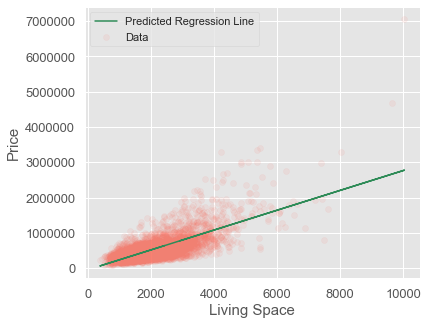

```python
if ENV_BHISHAN:
    from bhishan.util_model_plot import plot_simple_linear_regression

    plot_simple_linear_regression(Xtest, ytest, lr,"Living Space",'Price')
```

# Feature Selection

- Consider numeical columns: waterfront, view, condition, grade
- Binned columns: age and age_after_renovation
- Also take variables as numbers: zipcode, lat, long
- sqft_basement = sqft_living - sqft_above (so we can drop this column)
- Drop date columns and id column: id, date
- Optional features: yr_built, yr_renovated, yr_sales

```python
df_raw.head(2)
```

|  | id | date | price | bedrooms | bathrooms | sqft_living | sqft_lot | floors | waterfront | view | condition | grade | sqft_above | sqft_basement | yr_built | yr_renovated | zipcode | lat | long | sqft_living15 | sqft_lot15 | yr_sales | age | yr_renovated2 | age_after_renovation | zipcode_top10 | zipcode_houses | basement_bool | renovation_bool | … |
| --- | --- | --- | --- | --- | --- | --- | --- | --- | --- | --- | --- | --- | --- | --- | --- | --- | --- | --- | --- | --- | --- | --- | --- | --- | --- | --- | --- | --- | --- | --- |
| 0 | 7129300520 | 2014-10-13 | 221,900.000 | 3 | 1.000 | 1180 | 5650 | 1.000 | 0 | 0 | 3 | 7 | 1180 | 0 | 1955 | 0 | 98178 | 47.511 | -122.257 | 1340 | 5650 | 2014 | 59 | 1955 | 59 | others | 262 | 0 | 0 | … |
| 1 | 6414100192 | 2014-12-09 | 538,000.000 | 3 | 2.250 | 2570 | 7242 | 2.000 | 0 | 0 | 3 | 7 | 2170 | 400 | 1951 | 1991 | 98125 | 47.721 | -122.319 | 1690 | 7639 | 2014 | 63 | 1991 | 23 | others | 410 | 1 | 1 | … |

```python
df_raw.columns
```

```
Index(['id', 'date', 'price', 'bedrooms', 'bathrooms', 'sqft_living',
       'sqft_lot', 'floors', 'waterfront', 'view', 'condition', 'grade',
       'sqft_above', 'sqft_basement', 'yr_built', 'yr_renovated', 'zipcode',
       'lat', 'long', 'sqft_living15', 'sqft_lot15', 'yr_sales', 'age',
       'yr_renovated2', 'age_after_renovation', 'zipcode_top10',
       'zipcode_houses', 'basement_bool', 'renovation_bool', 'age_cat',
       'age_after_renovation_cat', 'waterfront_0', 'waterfront_1', 'view_0',
       'view_1', 'view_2', 'view_3', 'view_4', 'condition_1', 'condition_2',
       'condition_3', 'condition_4', 'condition_5', 'grade_1', 'grade_10',
       'grade_11', 'grade_12', 'grade_13', 'grade_3', 'grade_4', 'grade_5',
       'grade_6', 'grade_7', 'grade_8', 'grade_9', 'zipcode_top10_98004',
       'zipcode_top10_98006', 'zipcode_top10_98033', 'zipcode_top10_98039',
       'zipcode_top10_98040', 'zipcode_top10_98102', 'zipcode_top10_98105',
       'zipcode_top10_98155', 'zipcode_top10_98177', 'zipcode_top10_others',
       'age_cat_0', 'age_cat_1', 'age_cat_2', 'age_cat_3', 'age_cat_4',
       'age_cat_5', 'age_cat_6', 'age_cat_7', 'age_cat_8', 'age_cat_9',
       'age_after_renovation_cat_0', 'age_after_renovation_cat_1',
       'age_after_renovation_cat_2', 'age_after_renovation_cat_3',
       'age_after_renovation_cat_4', 'age_after_renovation_cat_5',
       'age_after_renovation_cat_6', 'age_after_renovation_cat_7',
       'age_after_renovation_cat_8', 'age_after_renovation_cat_9',
       'log1p_price', 'log1p_sqft_living', 'log1p_sqft_lot',
       'log1p_sqft_above', 'log1p_sqft_basement', 'log1p_sqft_living15',
       'log1p_sqft_lot15'],
      dtype='object')
```

```python
features_raw_few = ['bedrooms','bathrooms','sqft_living',
                    'sqft_lot','floors','zipcode']
```

```python
features_raw_all = ['bedrooms','bathrooms','sqft_living','sqft_lot',
                    'floors','waterfront','view','condition','grade',
                    'sqft_above','yr_built','yr_renovated',
                    'zipcode','lat','long','sqft_living15','sqft_lot15']
```

```python
df.columns
```

```
Index(['id', 'date', 'price', 'bedrooms', 'bathrooms', 'sqft_living',
       'sqft_lot', 'floors', 'waterfront', 'view', 'condition', 'grade',
       'sqft_above', 'sqft_basement', 'yr_built', 'yr_renovated', 'zipcode',
       'lat', 'long', 'sqft_living15', 'sqft_lot15', 'yr_sales', 'age',
       'yr_renovated2', 'age_after_renovation', 'zipcode_top10',
       'zipcode_houses', 'basement_bool', 'renovation_bool', 'age_cat',
       'age_after_renovation_cat', 'waterfront_0', 'waterfront_1', 'view_0',
       'view_1', 'view_2', 'view_3', 'view_4', 'condition_1', 'condition_2',
       'condition_3', 'condition_4', 'condition_5', 'grade_1', 'grade_10',
       'grade_11', 'grade_12', 'grade_13', 'grade_3', 'grade_4', 'grade_5',
       'grade_6', 'grade_7', 'grade_8', 'grade_9', 'zipcode_top10_98004',
       'zipcode_top10_98006', 'zipcode_top10_98033', 'zipcode_top10_98039',
       'zipcode_top10_98040', 'zipcode_top10_98102', 'zipcode_top10_98105',
       'zipcode_top10_98155', 'zipcode_top10_98177', 'zipcode_top10_others',
       'age_cat_0', 'age_cat_1', 'age_cat_2', 'age_cat_3', 'age_cat_4',
       'age_cat_5', 'age_cat_6', 'age_cat_7', 'age_cat_8', 'age_cat_9',
       'age_after_renovation_cat_0', 'age_after_renovation_cat_1',
       'age_after_renovation_cat_2', 'age_after_renovation_cat_3',
       'age_after_renovation_cat_4', 'age_after_renovation_cat_5',
       'age_after_renovation_cat_6', 'age_after_renovation_cat_7',
       'age_after_renovation_cat_8', 'age_after_renovation_cat_9',
       'log1p_price', 'log1p_sqft_living', 'log1p_sqft_lot',
       'log1p_sqft_above', 'log1p_sqft_basement', 'log1p_sqft_living15',
       'log1p_sqft_lot15'],
      dtype='object')
```

```python
df.filter(regex='age').columns
```

```
Index(['age', 'age_after_renovation', 'age_cat', 'age_after_renovation_cat',
       'age_cat_0', 'age_cat_1', 'age_cat_2', 'age_cat_3', 'age_cat_4',
       'age_cat_5', 'age_cat_6', 'age_cat_7', 'age_cat_8', 'age_cat_9',
       'age_after_renovation_cat_0', 'age_after_renovation_cat_1',
       'age_after_renovation_cat_2', 'age_after_renovation_cat_3',
       'age_after_renovation_cat_4', 'age_after_renovation_cat_5',
       'age_after_renovation_cat_6', 'age_after_renovation_cat_7',
       'age_after_renovation_cat_8', 'age_after_renovation_cat_9'],
      dtype='object')
```

```python
features_processed_cat_age = [ 'age_cat_0', 'age_cat_1', 'age_cat_2',
                               'age_cat_3', 'age_cat_4', 'age_cat_5',
                               'age_cat_6', 'age_cat_7', 'age_cat_8',
                               'age_cat_9']

features_processed_cat_agernv = [
                'age_after_renovation_cat_0','age_after_renovation_cat_1',
                'age_after_renovation_cat_2', 'age_after_renovation_cat_3',
                'age_after_renovation_cat_4', 'age_after_renovation_cat_5',
                'age_after_renovation_cat_6', 'age_after_renovation_cat_7',
                'age_after_renovation_cat_8', 'age_after_renovation_cat_9']


features_processed_few = features_raw_all + features_processed_cat_age
features_processed_many = (features_raw_all + features_processed_cat_age
                          + features_processed_cat_agernv)

print(features_processed_many)
```

```
['bedrooms', 'bathrooms', 'sqft_living', 'sqft_lot', 'floors', 'waterfront', 'view', 'condition', 'grade', 'sqft_above', 'yr_built', 'yr_renovated', 'zipcode', 'lat', 'long', 'sqft_living15', 'sqft_lot15', 'age_cat_0', 'age_cat_1', 'age_cat_2', 'age_cat_3', 'age_cat_4', 'age_cat_5', 'age_cat_6', 'ag…
```

```python
import io
import json

myjson = {
    'features_raw_few' : features_raw_few,
    'features_raw_all': features_raw_all,
    'features_processed_few': features_processed_few,
    'features_processed_many': features_processed_many
}

with io.open('../models/features_names.json', 'w', encoding='utf8') as fo:
    str_ = json.dumps(myjson,
                      indent=4,
                      sort_keys=False,
                      separators=(',', ': '),
                      ensure_ascii=False)
    fo.write(str(str_))
```

# Multiple Linear Regression

When we have more than one features to estimate the target, it is called multiple linear regression. The equation of the model is given below:

$$ h_{\theta}(X)=\theta_{0}+\theta_{1} x_{1}+\theta_{2} x_{2}+\ldots+\theta_{n} x_{n} $$

For multiple linear regression we also have Adjusted R-squared values to better account additional number of features used.

$$ \overline{R^{2}}=R^{2}-\frac{k-1}{n-k}\left(1-R^{2}\right) $$

where `n` is the number of observations and `k` is the number of parameters.

```python
def adjustedR2(rsquared,nrows,kcols):
    return rsquared- (kcols-1)/(nrows-kcols) * (1-rsquared)
```

```python
def multiple_linear_regression(model,X,y, Xtrain, ytrain, Xtest,ytest,cv=5):
    """ Multiple Linear Regression Modelling using given model.


    Returns:
    rmse, r2_train, ar2_train, r2_test, ar2_test, cv
    """
    def adjustedR2(rsquared,nrows,kcols):
        return rsquared- (kcols-1)/(nrows-kcols) * (1-rsquared)

    # fitting
    model.fit(Xtrain,ytrain)

    # prediction
    ypreds = model.predict(Xtest)

    # metrics
    rmse = np.sqrt(mean_squared_error(ytest,ypreds)).round(3)
    r2_train = model.score(Xtrain, ytrain).round(3)
    r2_test = model.score(Xtest, ytest).round(3)

    cv = cross_val_score(model, X, y, cv=5,n_jobs=-1).mean().round(3)

    ar2_train = adjustedR2(model.score(Xtrain,ytrain),
                           Xtrain.shape[0],
                           len(features)).round(3)
    ar2_test  = adjustedR2(model.score(Xtest,ytest),
                           Xtest.shape[0] ,
                           len(features)).round(3)

    return (rmse, r2_train, ar2_train, r2_test, ar2_test, cv)
```

```python
features = features_raw_few
target = ['price']

df = df_raw[features_raw_few + target]

X = df[features].values
y = df[target].values.reshape(-1,1)

Xtrain = train[features].values
ytrain = train[target].values.reshape(-1,1)

Xtest = test[features].values
ytest = test[target].values.reshape(-1,1)

model = linear_model.LinearRegression()
rmse, r2_train, ar2_train, r2_test, ar2_test, cv = \
    multiple_linear_regression(model,X,y, Xtrain, ytrain, Xtest,ytest)


df_eval.loc[len(df_eval)] = ['Multiple Linear Regression','few features, unprocessed',
                    rmse,r2_train,ar2_train,r2_test,ar2_test,cv]

df_eval
```

|  | Model | Details | Root Mean Squared Error (RMSE) | R-squared (training) | Adjusted R-squared (training) | R-squared (test) | Adjusted R-squared (test) | 5-Fold Cross Validation |
| --- | --- | --- | --- | --- | --- | --- | --- | --- |
| 0 | Simple Linear Regression | - | 255,511.380 | 0.487 | 0.487 | 0.516 | 0.516 | 0.491 |
| 1 | Multiple Linear Regression | few features, unprocessed | 250,717.169 | 0.510 | 0.510 | 0.534 | 0.533 | 0.512 |

## Multiple Linear Regression - Some processed features

```python
features = features_processed_few
target = ['price']

df = df_raw[features + target]

X = df[features].values
y = df[target].values.reshape(-1,1)

X_train = train[features].values
y_train = train[target].values.reshape(-1,1)

X_test = test[features].values
y_test = test[target].values.reshape(-1,1)

model = linear_model.LinearRegression()
rmse, r2_train, ar2_train, r2_test, ar2_test, cv = \
    multiple_linear_regression(model,X,y, Xtrain, ytrain, Xtest,ytest)

row = df_eval.shape[0]
df_eval.loc[row] = ['Multiple Linear Regression','few features, processed',
                    rmse,r2_train,ar2_train,r2_test,ar2_test,cv]

df_eval
```

|  | Model | Details | Root Mean Squared Error (RMSE) | R-squared (training) | Adjusted R-squared (training) | R-squared (test) | Adjusted R-squared (test) | 5-Fold Cross Validation |
| --- | --- | --- | --- | --- | --- | --- | --- | --- |
| 0 | Simple Linear Regression | - | 255,511.380 | 0.487 | 0.487 | 0.516 | 0.516 | 0.491 |
| 1 | Multiple Linear Regression | few features, unprocessed | 250,717.169 | 0.510 | 0.510 | 0.534 | 0.533 | 0.512 |
| 2 | Multiple Linear Regression | few features, processed | 250,717.169 | 0.510 | 0.510 | 0.534 | 0.531 | 0.702 |

## Multiple Linear Regression - Many processed features

All raw features + age_binned + age_renovated_binned

```python
features = features_processed_many
target = ['price']

df = df_raw[features + target]

X = df[features].values
y = df[target].values.reshape(-1,1)

Xtrain = train[features].values
ytrain = train[target].values.reshape(-1,1)

Xtest = test[features].values
ytest = test[target].values.reshape(-1,1)

model = linear_model.LinearRegression()
rmse, r2_train, ar2_train, r2_test, ar2_test, cv =\
    multiple_linear_regression(model,X,y, Xtrain, ytrain, Xtest,ytest)

row = df_eval.shape[0]
df_eval.loc[row] = ['Multiple Linear Regression','many features, processed',
                    rmse,r2_train,ar2_train,r2_test,ar2_test,cv]

df_eval
```

|  | Model | Details | Root Mean Squared Error (RMSE) | R-squared (training) | Adjusted R-squared (training) | R-squared (test) | Adjusted R-squared (test) | 5-Fold Cross Validation |
| --- | --- | --- | --- | --- | --- | --- | --- | --- |
| 0 | Simple Linear Regression | - | 255,511.380 | 0.487 | 0.487 | 0.516 | 0.516 | 0.491 |
| 1 | Multiple Linear Regression | few features, unprocessed | 250,717.169 | 0.510 | 0.510 | 0.534 | 0.533 | 0.512 |
| 2 | Multiple Linear Regression | few features, processed | 250,717.169 | 0.510 | 0.510 | 0.534 | 0.531 | 0.702 |
| 3 | Multiple Linear Regression | many features, processed | 197,259.488 | 0.706 | 0.706 | 0.711 | 0.709 | 0.704 |

## Multiple Linear Regrerssion - Ridge Regularization L2

- Overfitting: complicated model and too many features. Drop unnecessary featrures.
- Underfitting: very simple model. Add more features.

Popular regularization methods:

- Ridge: use when many small/medium sized effects on target.
- Lasso: Use when few variables with medium/large effects on target.

Ridge regression is called L2 regularization and by adding a penalty, we obtain the below equation $$ R S S_{R I D G E}=\sum_{i=1}^{m}\left(h_{\theta}\left(x_{i}\right)-y_{i}\right)^{2}+\alpha \sum_{j=1}^{n} \theta_{j}^{2} $$

```python
features = features_processed_many
target = ['price']

df = df_raw[features+target]

X = df[features].values
y = df[target].values.reshape(-1,1)

Xtrain = train[features].values
ytrain = train[target].values.reshape(-1,1)

Xtest = test[features].values
ytest = test[target].values.reshape(-1,1)

model = linear_model.Ridge(alpha=1)

rmse, r2_train, ar2_train, r2_test, ar2_test, cv = \
    multiple_linear_regression(model,X,y, Xtrain, ytrain, Xtest,ytest)

row = df_eval.shape[0]
df_eval.loc[row] = ['Multiple Linear Regression Ridge Regularization (L2)',
                    'alpha=1, many features, processed',
                    rmse,r2_train,ar2_train,r2_test,ar2_test,cv]
```

```python
features = features_processed_many
target = ['price']

df = df_raw[features+target]

X = df[features].values
y = df[target].values.reshape(-1,1)

Xtrain = train[features].values
ytrain = train[target].values.reshape(-1,1)

Xtest = test[features].values
ytest = test[target].values.reshape(-1,1)

model = linear_model.Ridge(alpha=1000)

rmse, r2_train, ar2_train, r2_test, ar2_test, cv = \
    multiple_linear_regression(model,X,y, Xtrain, ytrain, Xtest,ytest)

row = df_eval.shape[0]
df_eval.loc[row] = ['Multiple Linear Regression Ridge Regularization (L2)',
                    'alpha=1000, many features, processed',
                    rmse,r2_train,ar2_train,r2_test,ar2_test,cv]
```

## Multiple Linear Regression - Lasso Regularization L1

- Lasso regularization makes some model coefficients exactly zero.

> Technically the Lasso model is optimizing the same objective function as the Elastic Net with l1_ratio=1.0 (no L2 penalty).

> The optimization objective for Lasso is:

(1 / (2 *n_samples))* ||y - Xw||^2_2 + alpha * ||w||_1

```python
features = features_processed_many
target = ['price']

df = df_raw[features+target]

X = df[features].values
y = df[target].values.reshape(-1,1)

Xtrain = train[features].values
ytrain = train[target].values.reshape(-1,1)

Xtest = test[features].values
ytest = test[target].values.reshape(-1,1)

model = linear_model.Lasso(alpha=1, random_state=SEED)

rmse, r2_train, ar2_train, r2_test, ar2_test, cv = \
    multiple_linear_regression(model,X,y, Xtrain, ytrain, Xtest,ytest)

row = df_eval.shape[0]
df_eval.loc[row] = ['Multiple Linear Regression Lasso Regularization (L1)',
                    'alpha=1, many features, processed',
                    rmse,r2_train,ar2_train,r2_test,ar2_test,cv]
```

```python
features = features_processed_many

target = ['price']

df = df_raw[features+target]

X = df[features].values
y = df[target].values.reshape(-1,1)

Xtrain = train[features].values
ytrain = train[target].values.reshape(-1,1)

Xtest = test[features].values
ytest = test[target].values.reshape(-1,1)

model = linear_model.Lasso(alpha=100,random_state=SEED)

rmse, r2_train, ar2_train, r2_test, ar2_test, cv = \
    multiple_linear_regression(model,X,y, Xtrain, ytrain, Xtest,ytest)


df_eval.loc[len(df_eval)] = ['Multiple Linear Regression Lasso Regularization',
                    'alpha=100, many features, processed',
                    rmse,r2_train,ar2_train,r2_test,ar2_test,cv]

df_eval
```

|  | Model | Details | Root Mean Squared Error (RMSE) | R-squared (training) | Adjusted R-squared (training) | R-squared (test) | Adjusted R-squared (test) | 5-Fold Cross Validation |
| --- | --- | --- | --- | --- | --- | --- | --- | --- |
| 0 | Simple Linear Regression | - | 255,511.380 | 0.487 | 0.487 | 0.516 | 0.516 | 0.491 |
| 1 | Multiple Linear Regression | few features, unprocessed | 250,717.169 | 0.510 | 0.510 | 0.534 | 0.533 | 0.512 |
| 2 | Multiple Linear Regression | few features, processed | 250,717.169 | 0.510 | 0.510 | 0.534 | 0.531 | 0.702 |
| 3 | Multiple Linear Regression | many features, processed | 197,259.488 | 0.706 | 0.706 | 0.711 | 0.709 | 0.704 |
| 4 | Multiple Linear Regression Ridge Regularization (L2) | alpha=1, many features, processed | 197,256.275 | 0.706 | 0.706 | 0.711 | 0.709 | 0.704 |
| 5 | Multiple Linear Regression Ridge Regularization (L2) | alpha=1000, many features, processed | 210,224.755 | 0.664 | 0.663 | 0.672 | 0.669 | 0.661 |
| 6 | Multiple Linear Regression Lasso Regularization (L1) | alpha=1, many features, processed | 197,259.114 | 0.706 | 0.706 | 0.711 | 0.709 | 0.704 |
| 7 | Multiple Linear Regression Lasso Regularization | alpha=100, many features, processed | 197,276.866 | 0.706 | 0.706 | 0.711 | 0.709 | 0.704 |

# Polynomial Regression

## Polynomial Regression - deg = 2 few raw features

```python
features = features_raw_few
target = ['price']

df = df_raw[features+target]

polyfeat = PolynomialFeatures(degree=2)

X = polyfeat.fit_transform(df[features])

Xtrain = polyfeat.fit_transform(train[features])
Xtest = polyfeat.fit_transform(test[features])

y = df[target].values.reshape(-1,1)
ytrain = train[target].values.reshape(-1,1)
ytest = test[target].values.reshape(-1,1)


model = linear_model.LinearRegression(n_jobs=-1)

rmse, r2_train, ar2_train, r2_test, ar2_test, cv = \
    multiple_linear_regression(model,X,y, Xtrain, ytrain, Xtest,ytest)

row = df_eval.shape[0]
df_eval.loc[row] = ['Polynomial Regression','deg=2, few features,\
                     unprocessed, no regularization',
                    rmse,r2_train,ar2_train,r2_test,ar2_test,cv]
```

## Polynomial Regression - deg = 3 few raw features

```python
features = features_raw_few
target = ['price']

df = df_raw[features+target]

polyfeat = PolynomialFeatures(degree=3)

X = polyfeat.fit_transform(df[features])

Xtrain = polyfeat.fit_transform(train[features])
Xtest = polyfeat.fit_transform(test[features])

y = df[target].values.reshape(-1,1)
ytrain = train[target].values.reshape(-1,1)
ytest = test[target].values.reshape(-1,1)


model = linear_model.LinearRegression(n_jobs=-1)

rmse, r2_train, ar2_train, r2_test, ar2_test, cv = \
    multiple_linear_regression(model,X,y, Xtrain, ytrain, Xtest,ytest)

row = df_eval.shape[0]
df_eval.loc[row] = ['Polynomial Regression','deg=3, \
                     few features, unprocessed, no regularization',
                    rmse,r2_train,ar2_train,r2_test,ar2_test,cv]
```

## Polynomial Regression - deg = 2 all raw features

```python
features = features_raw_all
target = ['price']

df = df_raw[features+target]


polyfeat = PolynomialFeatures(degree=2)

X = polyfeat.fit_transform(df[features])

Xtrain = polyfeat.fit_transform(train[features])
Xtest = polyfeat.fit_transform(test[features])

y = df[target].values.reshape(-1,1)
ytrain = train[target].values.reshape(-1,1)
ytest = test[target].values.reshape(-1,1)


model = linear_model.LinearRegression(n_jobs=-1)

rmse, r2_train, ar2_train, r2_test, ar2_test, cv = \
    multiple_linear_regression(model,X,y, Xtrain, ytrain, Xtest,ytest)

row = df_eval.shape[0]
df_eval.loc[row] = ['Polynomial Regression','deg=2, all features,\
                     unprocessed, no regularization',
                    rmse,r2_train,ar2_train,r2_test,ar2_test,cv]
```

## Polynomial Regression - deg = 3 all raw features

```python
features = features_raw_all
target = ['price']

df = df_raw[features+target]

polyfeat = PolynomialFeatures(degree=3)

X = polyfeat.fit_transform(df[features])

X_train = polyfeat.fit_transform(train[features])
X_test = polyfeat.fit_transform(test[features])

y = df[target].values.reshape(-1,1)
y_train = train[target].values.reshape(-1,1)
y_test = test[target].values.reshape(-1,1)


model = linear_model.LinearRegression(n_jobs=-1)

rmse, r2_train, ar2_train, r2_test, ar2_test, cv = \
    multiple_linear_regression(model,X,y, Xtrain, ytrain, Xtest,ytest)

row = df_eval.shape[0]
df_eval.loc[row] = ['Polynomial Regression','deg =3, all features,\
                     unprocessed, no regularization',
                    rmse,r2_train,ar2_train,r2_test,ar2_test,cv]
```

## Polynomial Regression - deg = 2 many processed features

```python
time_start = time.time()


features = features_processed_many
target = ['price']

df = df_raw[features+target]


polyfeat = PolynomialFeatures(degree=2)

X = polyfeat.fit_transform(df[features])

Xtrain = polyfeat.fit_transform(train[features])
Xtest = polyfeat.fit_transform(test[features])

y = df[target].values.reshape(-1,1)
ytrain = train[target].values.reshape(-1,1)
ytest = test[target].values.reshape(-1,1)


model = linear_model.LinearRegression(n_jobs=-1)

rmse, r2_train, ar2_train, r2_test, ar2_test, cv = \
    multiple_linear_regression(model,X,y, Xtrain, ytrain, Xtest,ytest)

row = df_eval.shape[0]

time_taken = time.time() - time_start
print('Time taken: {:.0f} min {:.0f} secs'.format(*divmod(time_taken,60)))

df_eval.loc[row] = ['Polynomial Regression','deg =2, many features,\
                     processed, no regularization',
                    rmse,r2_train,ar2_train,r2_test,ar2_test,cv]
```

```
Time taken: 0 min 7 secs
```

## Polynomial Regression - deg = 2 many processed features Ridge alpha = 1

```python
time_start = time.time()


features = features_processed_many
target = ['price']

df = df_raw[features+target]

polyfeat = PolynomialFeatures(degree=2)

X = polyfeat.fit_transform(df[features])

Xtrain = polyfeat.fit_transform(train[features])
Xtest = polyfeat.fit_transform(test[features])

y = df[target].values.reshape(-1,1)
ytrain = train[target].values.reshape(-1,1)
ytest = test[target].values.reshape(-1,1)


model = linear_model.Ridge(alpha=1,random_state=SEED)

rmse, r2_train, ar2_train, r2_test, ar2_test, cv = \
    multiple_linear_regression(model,X,y, Xtrain, ytrain, Xtest,ytest)

row = df_eval.shape[0]
df_eval.loc[row] = ['Polynomial Regression','deg=2, many features,\
                     processed, Ridge alpha=1',
                    rmse,r2_train,ar2_train,r2_test,ar2_test,cv]

time_taken = time.time() - time_start
print('Time taken: {:.0f} min {:.0f} secs'.format(*divmod(time_taken,60)))
```

```
Time taken: 0 min 3 secs
```

## Polynomial Regression - deg = 2 many processed features Ridge alpha = 50_000

```python
features = features_processed_many
target = ['price']

df = df_raw[features+target]

polyfeat = PolynomialFeatures(degree=2)

X = polyfeat.fit_transform(df[features])

Xtrain = polyfeat.fit_transform(train[features])
Xtest = polyfeat.fit_transform(test[features])

y = df[target].values.reshape(-1,1)
ytrain = train[target].values.reshape(-1,1)
ytest = test[target].values.reshape(-1,1)


model = linear_model.Ridge(alpha=50000,random_state=SEED)

rmse, r2_train, ar2_train, r2_test, ar2_test, cv = \
    multiple_linear_regression(model,X,y, Xtrain, ytrain, Xtest,ytest)

row = df_eval.shape[0]
df_eval.loc[row] = ['Polynomial Regression','deg =2, many features, processed,\
                     Ridge alpha=50000',
                    rmse,r2_train,ar2_train,r2_test,ar2_test,cv]
```

## Polynomial Regression - deg = 2 many processed features Lasso alpha = 1

```python
time_start = time.time()


features = features_processed_many
target = ['price']

df = df_raw[features+target]

polyfeat = PolynomialFeatures(degree=2)

X = polyfeat.fit_transform(df[features])

Xtrain = polyfeat.fit_transform(train[features])
Xtest = polyfeat.fit_transform(test[features])

y = df[target].values.reshape(-1,1)
ytrain = train[target].values.reshape(-1,1)
ytest = test[target].values.reshape(-1,1)


model = linear_model.Lasso(alpha=1,random_state=SEED)

rmse, r2_train, ar2_train, r2_test, ar2_test, cv = \
    multiple_linear_regression(model,X,y, Xtrain, ytrain, Xtest,ytest)

row = df_eval.shape[0]
df_eval.loc[row] = ['Polynomial Regression','deg=2, all features,\
                     processed, Lasso alpha=1',
                    rmse,r2_train,ar2_train,r2_test,ar2_test,cv]

time_taken = time.time() - time_start
print('Time taken: {:.0f} min {:.0f} secs'.format(*divmod(time_taken,60)))
```

```
Time taken: 0 min 45 secs
```

## Polynomial Regression - deg = 2 many processed features Lasso alpha = 50_000

```python
time_start = time.time()


features = features_processed_many
target = ['price']

df = df_raw[features+target]

polyfeat = PolynomialFeatures(degree=2)

X = polyfeat.fit_transform(df[features])

Xtrain = polyfeat.fit_transform(train[features])
Xtest = polyfeat.fit_transform(test[features])

y = df[target].values.reshape(-1,1)
ytrain = train[target].values.reshape(-1,1)
ytest = test[target].values.reshape(-1,1)


model = linear_model.Lasso(alpha=50000,random_state=SEED)

rmse, r2_train, ar2_train, r2_test, ar2_test, cv = \
    multiple_linear_regression(model,X,y, Xtrain, ytrain, Xtest,ytest)


df_eval.loc[len(df_eval)] = ['Polynomial Regression','deg =2, all features,\
                    processed, Lasso alpha=50000',
                    rmse,r2_train,ar2_train,r2_test,ar2_test,cv]

time_taken = time.time() - time_start
print('Time taken: {:.0f} min {:.0f} secs'.format(*divmod(time_taken,60)))
```

```
Time taken: 0 min 35 secs
```

## Linear Model LassoLarsCV

Notes

> The object solves the same problem as the LassoCV object. However, unlike the LassoCV, it find the relevant alphas values by itself. In general, because of this property, it will be more stable. However, it is more fragile to heavily multicollinear datasets.

> It is more efficient than the LassoCV if only a small number of features are selected compared to the total number, for instance if there are very few samples compared to the number of features.

```python
def adjustedR2(rsquared,nrows,kcols):
    return rsquared- (kcols-1)/(nrows-kcols) * (1-rsquared)
```

```python
from sklearn.linear_model import LassoLarsCV

time_start = time.time()


features = features_processed_many
target = ['price']

df = df_raw[features+target]


X = df[features].values
y = df[target].values.reshape(-1,1)

Xtrain = train[features].values
ytrain = train[target].values.reshape(-1,1)

Xtest = test[features].values
ytest = test[target].values.reshape(-1,1)

model = linear_model.LassoLarsCV(cv=5,n_jobs=-1,verbose=2,max_iter=1000)

# fitting
model.fit(Xtrain,ytrain)

# prediction
ypreds = model.predict(Xtest)

# metrics
rmse = np.sqrt(mean_squared_error(ytest,ypreds)).round(3)
r2_train = model.score(Xtrain, ytrain).round(3)
r2_test = model.score(Xtest, ytest).round(3)


# rows and cols
nrows = df.shape[0]
kcols = len(features)

# adjusted rsquared
ar2_train = adjustedR2(r2_train,nrows,kcols)
ar2_test = adjustedR2(r2_test,nrows,kcols)



df_eval.loc[len(df_eval)] = ['Linear Regression LassoLarsCV',
                    'many features processed',
                    rmse,r2_train,ar2_train,r2_test,ar2_test,cv]

time_taken = time.time() - time_start
print('Time taken: {:.0f} min {:.0f} secs'.format(*divmod(time_taken,60)))
```

```
.Time taken: 0 min 0 secs
```

```
[Parallel(n_jobs=-1)]: Done   5 out of   5 | elapsed:    0.2s finished
```

# Summary

```python
%%javascript
IPython.OutputArea.auto_scroll_threshold = 9999;
```

```python
# Jupyter notebook settings for pandas
pd.set_option('display.max_columns', 200)
pd.set_option('display.max_rows', 100) # None for all the rows
```

```python
df_eval.sort_values('Adjusted R-squared (test)',ascending=False)
```

|  | Model | Details | Root Mean Squared Error (RMSE) | R-squared (training) | Adjusted R-squared (training) | R-squared (test) | Adjusted R-squared (test) | 5-Fold Cross Validation |
| --- | --- | --- | --- | --- | --- | --- | --- | --- |
| 10 | Polynomial Regression | deg=2, all features, unprocessed, no regularization | 158,822.055 | 0.831 | 0.831 | 0.813 | 0.812 | 0.813 |
| 11 | Polynomial Regression | deg =3, all features, unprocessed, no regularization | 158,822.055 | 0.831 | 0.831 | 0.813 | 0.812 | -2.454 |
| 13 | Polynomial Regression | deg=2, many features, processed, Ridge alpha=1 | 159,185.146 | 0.846 | 0.846 | 0.812 | 0.810 | 0.808 |
| 14 | Polynomial Regression | deg =2, many features, processed, Ridge alpha=50000 | 165,440.773 | 0.821 | 0.820 | 0.797 | 0.795 | 0.792 |
| 15 | Polynomial Regression | deg=2, all features, processed, Lasso alpha=1 | 174,534.762 | 0.812 | 0.812 | 0.774 | 0.772 | 0.778 |
| 16 | Polynomial Regression | deg =2, all features, processed, Lasso alpha=50000 | 176,297.103 | 0.803 | 0.802 | 0.769 | 0.767 | 0.781 |
| 17 | Linear Regression LassoLarsCV | many features processed | 197,309.546 | 0.706 | 0.706 | 0.711 | 0.711 | 0.781 |
| 3 | Multiple Linear Regression | many features, processed | 197,259.488 | 0.706 | 0.706 | 0.711 | 0.709 | 0.704 |
| 4 | Multiple Linear Regression Ridge Regularization (L2) | alpha=1, many features, processed | 197,256.275 | 0.706 | 0.706 | 0.711 | 0.709 | 0.704 |
| 6 | Multiple Linear Regression Lasso Regularization (L1) | alpha=1, many features, processed | 197,259.114 | 0.706 | 0.706 | 0.711 | 0.709 | 0.704 |
| 7 | Multiple Linear Regression Lasso Regularization | alpha=100, many features, processed | 197,276.866 | 0.706 | 0.706 | 0.711 | 0.709 | 0.704 |
| 5 | Multiple Linear Regression Ridge Regularization (L2) | alpha=1000, many features, processed | 210,224.755 | 0.664 | 0.663 | 0.672 | 0.669 | 0.661 |
| 12 | Polynomial Regression | deg =2, many features, processed, no regularization | 229,581.128 | 0.849 | 0.848 | 0.609 | 0.606 | -3.857 |
| 9 | Polynomial Regression | deg=3, few features, unprocessed, no regularization | 237,502.457 | 0.584 | 0.584 | 0.581 | 0.581 | 0.490 |
| 8 | Polynomial Regression | deg=2, few features, unprocessed, no regularization | 237,956.794 | 0.569 | 0.568 | 0.580 | 0.579 | 0.540 |
| 1 | Multiple Linear Regression | few features, unprocessed | 250,717.169 | 0.510 | 0.510 | 0.534 | 0.533 | 0.512 |
| 2 | Multiple Linear Regression | few features, processed | 250,717.169 | 0.510 | 0.510 | 0.534 | 0.531 | 0.702 |
| 0 | Simple Linear Regression | - | 255,511.380 | 0.487 | 0.487 | 0.516 | 0.516 | 0.491 |

# Feature Importance for Lasso Regression

```python
from sklearn.linear_model import Lasso
from sklearn.feature_selection import SelectFromModel

target = ['price']
features = features_processed_many

df = df_raw[features+target]

X = df[features].values
y = df[target].values.reshape(-1,1)

Xtrain = train[features].values
ytrain = train[target].values.reshape(-1,1)

Xtest = test[features].values
ytest = test[target].values.reshape(-1,1)

# scaling
import joblib
from sklearn.preprocessing import StandardScaler

# for linear models scaling is useful
scaler = StandardScaler()
scaler.fit(Xtrain)

# persist the model for future use
joblib.dump(scaler, '../models/MinMaxScaler_features_processed_many.pkl')

# scale transform
Xtrain = scaler.transform(Xtrain)
Xtest = scaler.transform(Xtest)

model = linear_model.Lasso(alpha=0.05,random_state=SEED,
                           max_iter=10_000, tol=0.01)
model.fit(Xtrain, ytrain)

# persist the model for future use
joblib.dump(model, '../models/lasso_regression_alpha_05_features_processed_many.pkl')

# prediction
ypreds = model.predict(Xtest)

# metrics
rmse_test = np.sqrt(mean_squared_error(ytest,ypreds)).round(3)
r2_train = model.score(Xtrain, ytrain).round(3)
r2_test = model.score(Xtest, ytest).round(3)

# prints
print('model = Lasso with Standard Scaling and many processed features')
print('rmse test = ', rmse_test)
print('rsquared train = ', r2_train)
print('rsquared test = ', r2_test)
```

[output not shown]

```python
# Feature importance
```

```python
sel = SelectFromModel(Lasso(alpha=0.05, random_state=SEED,tol=0.01))

sel.fit(Xtrain, ytrain)

sel.get_support()
```

```
array([ True,  True,  True,  True,  True,  True,  True,  True,  True,
        True,  True,  True,  True,  True,  True,  True,  True,  True,
        True,  True,  True,  True,  True,  True,  True,  True,  True,
        True,  True,  True,  True,  True,  True,  True,  True,  True,
        True])
```

```python
selected_feat = train[features].columns[sel.get_support()]
selected_feat
```

```
Index(['bedrooms', 'bathrooms', 'sqft_living', 'sqft_lot', 'floors',
       'waterfront', 'view', 'condition', 'grade', 'sqft_above', 'yr_built',
       'yr_renovated', 'zipcode', 'lat', 'long', 'sqft_living15', 'sqft_lot15',
       'age_cat_0', 'age_cat_1', 'age_cat_2', 'age_cat_3', 'age_cat_4',
       'age_cat_5', 'age_cat_6', 'age_cat_7', 'age_cat_8', 'age_cat_9',
       'age_after_renovation_cat_0', 'age_after_renovation_cat_1',
       'age_after_renovation_cat_2', 'age_after_renovation_cat_3',
       'age_after_renovation_cat_4', 'age_after_renovation_cat_5',
       'age_after_renovation_cat_6', 'age_after_renovation_cat_7',
       'age_after_renovation_cat_8', 'age_after_renovation_cat_9'],
      dtype='object')
```

```python
print('total features: {}'.format(len(features)))
print('selected features: {}'.format(len(selected_feat)))

print('features with coefficients shrank to zero: {}'.format(
    np.sum(sel.estimator_.coef_ == 0)))
```

```
total features: 37
selected features: 37
features with coefficients shrank to zero: 0
```

```python
import io
import json

myjson = {'model': 'Lasso with alpha 0.05 and many processed features',
         'selected_features': selected_feat.values.tolist()}

with io.open('../models/lasso_alpha_005_selected_features.json', 'w', encoding='utf8') as fo:
    str_ = json.dumps(myjson,
                      indent=4,
                      sort_keys=True,
                      separators=(',', ': '),
                      ensure_ascii=False)
    fo.write(str(str_))
```

```python
# Laso evaluation
```

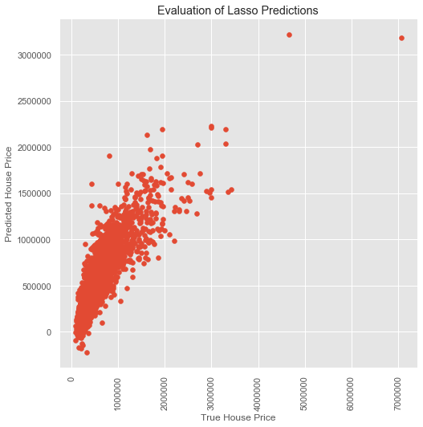

```python
plt.scatter(ytest, ypreds)
plt.xlabel('True House Price')
plt.ylabel('Predicted House Price')
plt.title('Evaluation of Lasso Predictions')
plt.xticks(rotation=90)
```

```python
errors = ytest.ravel() - ypreds.ravel()
errors
```

```
array([-131627.15561054,   -9655.37749367, -131804.98611956, ...,
        198212.68183312, -154168.31099857,   87765.5346244 ])
```

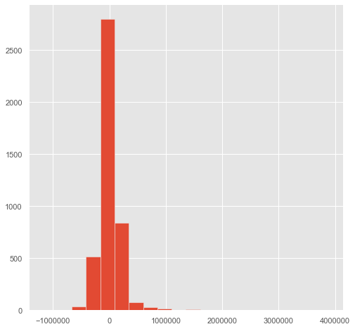

```python
plt.hist(errors, bins=20);
```

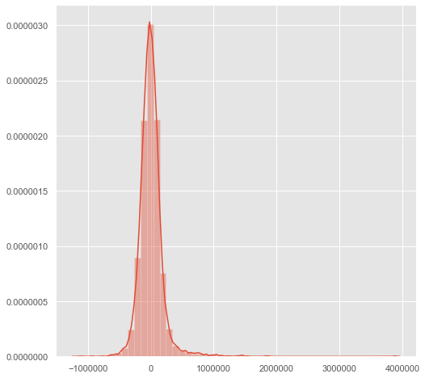

```python
sns.distplot(errors,norm_hist=True,) # errors should follow normal distribution
```

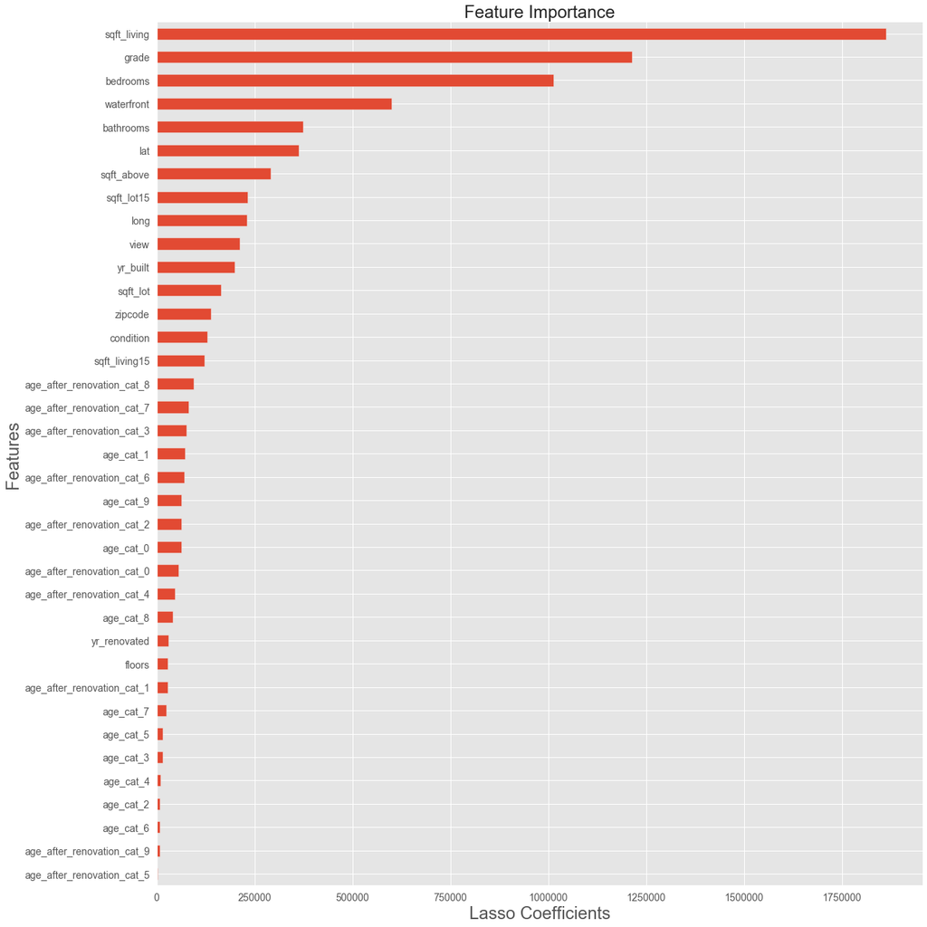

```python
ser_fimp = pd.Series(np.abs(model.coef_.ravel()))
ser_fimp.index = features
ser_fimp.sort_values(inplace=True)

ax = ser_fimp.plot.barh(figsize=(18,18))
ax.tick_params(axis='both', which='major', labelsize=14)

plt.xlabel('Lasso Coefficients',fontsize=24)
plt.ylabel('Features',fontsize=24)
plt.title('Feature Importance',fontsize=24)

plt.tight_layout()
plt.show()
```

# Best Model So Far

Best model: Polynomial Regression deg=2, all features, unprocessed, no regularization

```python
features = features_raw_all
target = ['price']

df = df_raw[features+target]


polyfeat = PolynomialFeatures(degree=2)

X = polyfeat.fit_transform(df[features])

Xtrain = polyfeat.fit_transform(train[features])
Xtest = polyfeat.fit_transform(test[features])

y = df[target].values.reshape(-1,1)
ytrain = train[target].values.reshape(-1,1)
ytest = test[target].values.reshape(-1,1)


model = linear_model.LinearRegression(n_jobs=-1)

rmse, r2_train, ar2_train, r2_test, ar2_test, cv = \
    multiple_linear_regression(model,X,y, Xtrain, ytrain, Xtest,ytest)

row = df_eval.shape[0]

print(ar2_test)
```

```
0.812
```

```python
df.head(2)
```

|  | bedrooms | bathrooms | sqft_living | sqft_lot | floors | waterfront | view | condition | grade | sqft_above | yr_built | yr_renovated | zipcode | lat | long | sqft_living15 | sqft_lot15 | price |
| --- | --- | --- | --- | --- | --- | --- | --- | --- | --- | --- | --- | --- | --- | --- | --- | --- | --- | --- |
| 0 | 3 | 1.000 | 1180 | 5650 | 1.000 | 0 | 0 | 3 | 7 | 1180 | 1955 | 0 | 98178 | 47.511 | -122.257 | 1340 | 5650 | 221,900.000 |
| 1 | 3 | 2.250 | 2570 | 7242 | 2.000 | 0 | 0 | 3 | 7 | 2170 | 1951 | 1991 | 98125 | 47.721 | -122.319 | 1690 | 7639 | 538,000.000 |

## Transform Target Regressor

```python
from sklearn.compose import TransformedTargetRegressor as TTR
from sklearn.preprocessing import StandardScaler

time_start = time.time()


X = polyfeat.fit_transform(df[features])

Xtrain = polyfeat.fit_transform(train[features])
Xtest = polyfeat.fit_transform(test[features])

y = df[target].values.reshape(-1,1)
ytrain = train[target].values.reshape(-1,1)
ytest = test[target].values.reshape(-1,1)

# for linear models scaling is useful
scaler = StandardScaler()
scaler.fit(Xtrain)

# scale transform
Xtrain = scaler.transform(Xtrain)
Xtest = scaler.transform(Xtest)


model = linear_model.LinearRegression(n_jobs=-1)

model = TTR(model, func=np.log1p, inverse_func=np.expm1)


model.fit(Xtrain,ytrain)

# prediction
ypreds = model.predict(Xtest)

# metrics
rmse_test = np.sqrt(mean_squared_error(ytest,ypreds)).round(3)
r2_train = model.score(Xtrain, ytrain).round(3)
r2_test = model.score(Xtest, ytest).round(3)

# prints
print('model = Best model')
print('rmse test = ', rmse_test)
print('rsquared train = ', r2_train)
print('rsquared test = ', r2_test)

df_eval.loc[len(df_eval)] = ['Linear Regression',
                    'all features, standard scaler, transform ytrain',
                    rmse,r2_train,ar2_train,r2_test,ar2_test,cv]

time_taken = time.time() - time_start
print('Time taken: {:.0f} min {:.0f} secs'.format(*divmod(time_taken,60)))

df_eval.sort_values('Adjusted R-squared (test)',ascending=False)
```

```
model = Best model
rmse test =  152548.214
rsquared train =  0.84
rsquared test =  0.827
Time taken: 0 min 0 secs
```

|  | Model | Details | Root Mean Squared Error (RMSE) | R-squared (training) | Adjusted R-squared (training) | R-squared (test) | Adjusted R-squared (test) | 5-Fold Cross Validation |
| --- | --- | --- | --- | --- | --- | --- | --- | --- |
| 18 | Linear Regression | all features, standard scaler, transform ytrain | 158,822.055 | 0.840 | 0.831 | 0.827 | 0.812 | 0.813 |
| 10 | Polynomial Regression | deg=2, all features, unprocessed, no regularization | 158,822.055 | 0.831 | 0.831 | 0.813 | 0.812 | 0.813 |
| 11 | Polynomial Regression | deg =3, all features, unprocessed, no regularization | 158,822.055 | 0.831 | 0.831 | 0.813 | 0.812 | -2.454 |
| 13 | Polynomial Regression | deg=2, many features, processed, Ridge alpha=1 | 159,185.146 | 0.846 | 0.846 | 0.812 | 0.810 | 0.808 |
| 14 | Polynomial Regression | deg =2, many features, processed, Ridge alpha=50000 | 165,440.773 | 0.821 | 0.820 | 0.797 | 0.795 | 0.792 |
| 15 | Polynomial Regression | deg=2, all features, processed, Lasso alpha=1 | 174,534.762 | 0.812 | 0.812 | 0.774 | 0.772 | 0.778 |
| 16 | Polynomial Regression | deg =2, all features, processed, Lasso alpha=50000 | 176,297.103 | 0.803 | 0.802 | 0.769 | 0.767 | 0.781 |
| 17 | Linear Regression LassoLarsCV | many features processed | 197,309.546 | 0.706 | 0.706 | 0.711 | 0.711 | 0.781 |
| 3 | Multiple Linear Regression | many features, processed | 197,259.488 | 0.706 | 0.706 | 0.711 | 0.709 | 0.704 |
| 4 | Multiple Linear Regression Ridge Regularization (L2) | alpha=1, many features, processed | 197,256.275 | 0.706 | 0.706 | 0.711 | 0.709 | 0.704 |
| 6 | Multiple Linear Regression Lasso Regularization (L1) | alpha=1, many features, processed | 197,259.114 | 0.706 | 0.706 | 0.711 | 0.709 | 0.704 |
| 7 | Multiple Linear Regression Lasso Regularization | alpha=100, many features, processed | 197,276.866 | 0.706 | 0.706 | 0.711 | 0.709 | 0.704 |
| 5 | Multiple Linear Regression Ridge Regularization (L2) | alpha=1000, many features, processed | 210,224.755 | 0.664 | 0.663 | 0.672 | 0.669 | 0.661 |
| 12 | Polynomial Regression | deg =2, many features, processed, no regularization | 229,581.128 | 0.849 | 0.848 | 0.609 | 0.606 | -3.857 |
| 9 | Polynomial Regression | deg=3, few features, unprocessed, no regularization | 237,502.457 | 0.584 | 0.584 | 0.581 | 0.581 | 0.490 |
| 8 | Polynomial Regression | deg=2, few features, unprocessed, no regularization | 237,956.794 | 0.569 | 0.568 | 0.580 | 0.579 | 0.540 |
| 1 | Multiple Linear Regression | few features, unprocessed | 250,717.169 | 0.510 | 0.510 | 0.534 | 0.533 | 0.512 |
| 2 | Multiple Linear Regression | few features, processed | 250,717.169 | 0.510 | 0.510 | 0.534 | 0.531 | 0.702 |
| 0 | Simple Linear Regression | - | 255,511.380 | 0.487 | 0.487 | 0.516 | 0.516 | 0.491 |